# Lista_2

Patrícia da Silva Ramos

2023-01-16

## R Markdown

```r
#install.package{"ggplot2"}
library(ggplot2)
#carregar conjunto de dados USArrests
data(USArrests)
mydata = USArrests
#ver a dimensão do banco de dados
dim(mydata)
```

```
## [1] 50  4
```

```r
head(mydata) #seis primeiras linhas
```

```
##            Murder Assault UrbanPop Rape
## Alabama      13.2     236       58 21.2
## Alaska       10.0     263       48 44.5
## Arizona       8.1     294       80 31.0
## Arkansas      8.8     190       50 19.5
## California    9.0     276       91 40.6
## Colorado      7.9     204       78 38.7
```

```r
tail(mydata) #seis últimas linhas
```

```
##               Murder Assault UrbanPop Rape
## Vermont          2.2      48       32 11.2
## Virginia         8.5     156       63 20.7
## Washington       4.0     145       73 26.2
## West Virginia    5.7      81       39  9.3
## Wisconsin        2.6      53       66 10.8
## Wyoming          6.8     161       60 15.6
```

```r
summary(mydata) # sumário estatístico do conjunto de dados
```

```
##      Murder          Assault         UrbanPop          Rape
##  Min.   : 0.800   Min.   : 45.0   Min.   :32.00   Min.   : 7.30
##  1st Qu.: 4.075   1st Qu.:109.0   1st Qu.:54.50   1st Qu.:15.07
##  Median : 7.250   Median :159.0   Median :66.00   Median :20.10
##  Mean   : 7.788   Mean   :170.8   Mean   :65.54   Mean   :21.23
##  3rd Qu.:11.250   3rd Qu.:249.0   3rd Qu.:77.75   3rd Qu.:26.18
##  Max.   :17.400   Max.   :337.0   Max.   :91.00   Max.   :46.00
```

```r
names(mydata) #nomes das variáveis
```

```
## [1] "Murder"   "Assault"  "UrbanPop" "Rape"
```

```r
row(mydata) #nomes dos estados norte-americanos
```

```
##       [,1] [,2] [,3] [,4]
##  [1,]    1    1    1    1
##  [2,]    2    2    2    2
##  [3,]    3    3    3    3
##  [4,]    4    4    4    4
##  [5,]    5    5    5    5
##  [6,]    6    6    6    6
##  [7,]    7    7    7    7
##  [8,]    8    8    8    8
##  [9,]    9    9    9    9
## [10,]   10   10   10   10
## [11,]   11   11   11   11
## [12,]   12   12   12   12
## [13,]   13   13   13   13
## [14,]   14   14   14   14
```

[output cut: 36 more lines]

## Exercício 01

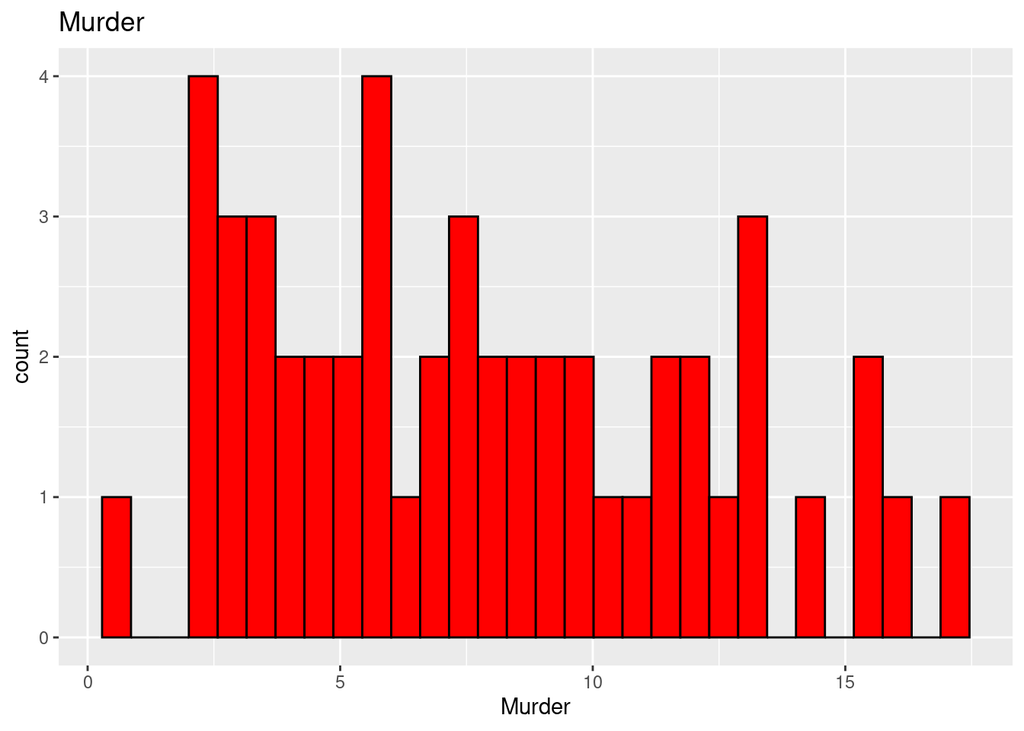

```r
library(ggplot2)

# Carregando o conjunto de dados USArrests
data("USArrests")

# Criando um histograma para cada variável usando cores diferentes
ggplot(USArrests, aes(x = Murder)) +
  geom_histogram(fill = "red", color = "black") +
  ggtitle("Murder")
```

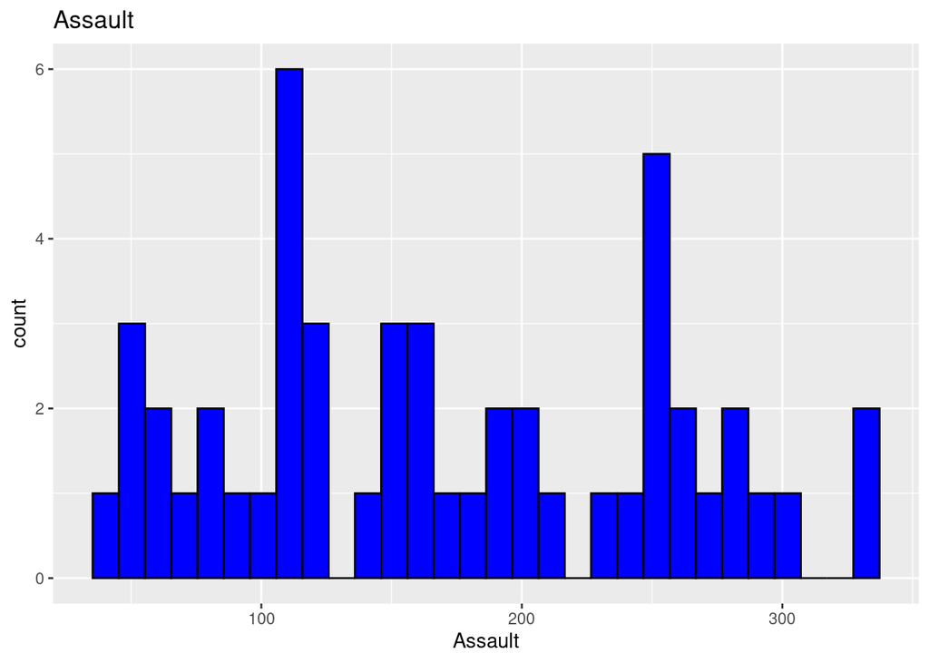

```r
ggplot(USArrests, aes(x = Assault)) +
  geom_histogram(fill = "blue", color = "black") +
  ggtitle("Assault")
```

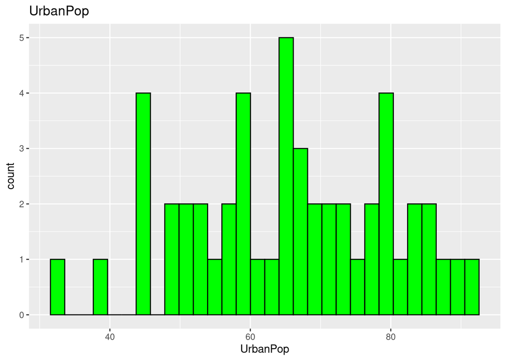

```r
ggplot(USArrests, aes(x = UrbanPop)) +
  geom_histogram(fill = "green", color = "black") +
  ggtitle("UrbanPop")
```

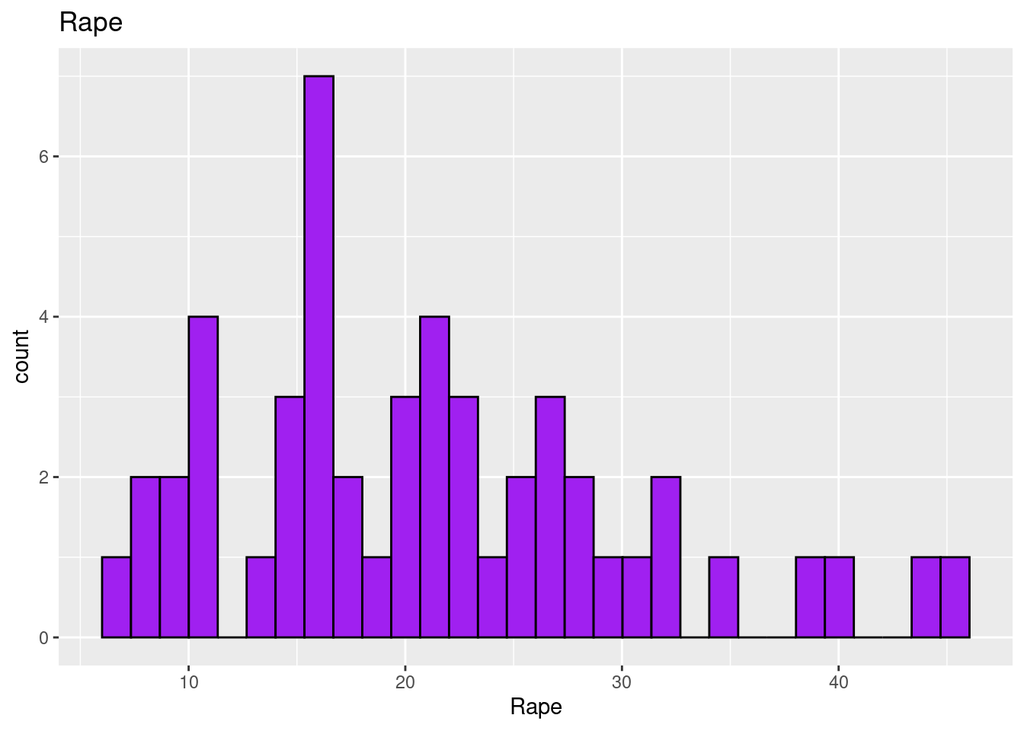

```r
ggplot(USArrests, aes(x = Rape)) +
  geom_histogram(fill = "purple", color = "black") +
  ggtitle("Rape")
```

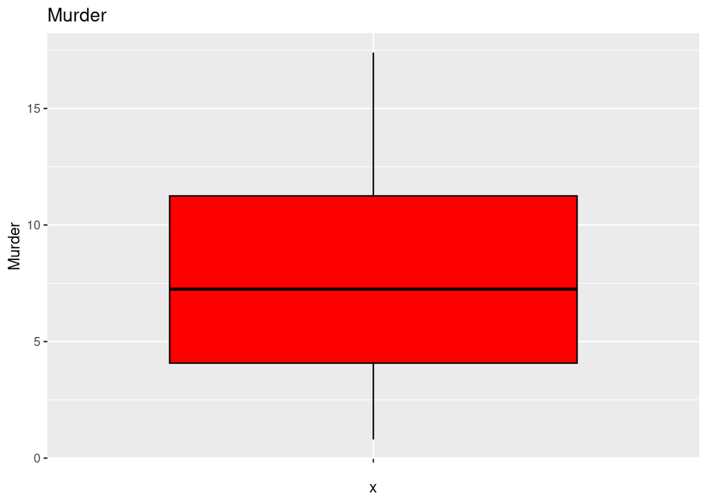

```r
# Carregando o conjunto de dados USArrests
data("USArrests")

# Criando um box-plot para cada variável usando cores diferentes
ggplot(USArrests, aes(x = "", y = Murder)) +
  geom_boxplot(fill = "red", color = "black") +
  ggtitle("Murder")
```

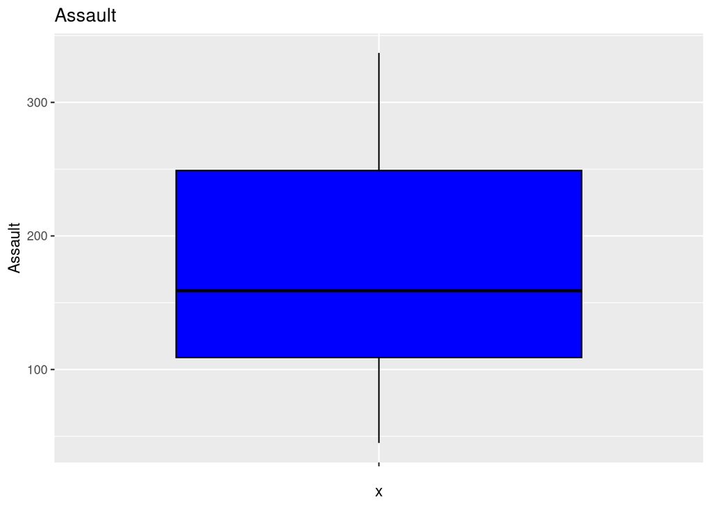

```r
ggplot(USArrests, aes(x = "", y = Assault)) +
  geom_boxplot(fill = "blue", color = "black") +
  ggtitle("Assault")
```

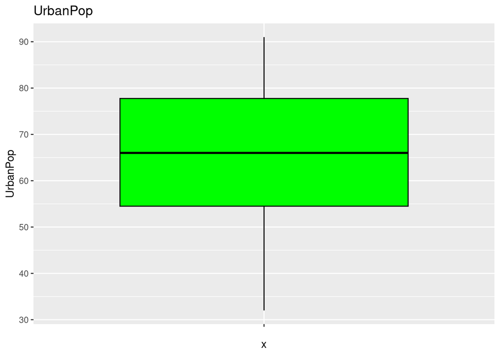

```r
ggplot(USArrests, aes(x = "", y = UrbanPop)) +
  geom_boxplot(fill = "green", color = "black") +
  ggtitle("UrbanPop")
```

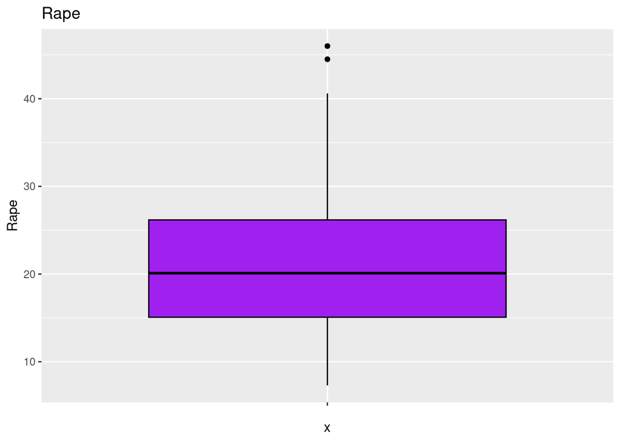

```r
ggplot(USArrests, aes(x = "", y = Rape)) +
  geom_boxplot(fill = "purple", color = "black") +
  ggtitle("Rape")
```

## Exercício 02

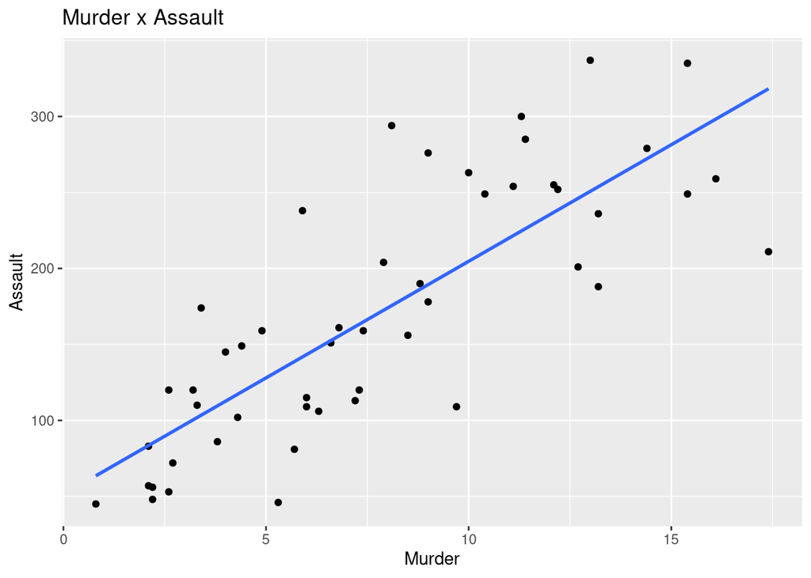

```r
#2)
#Gráfico de dispersão a fim de verificar como o nível de assassinatos
#se relaciona com a quantidade de assaltos

# Criando o scatterplot
ggplot(data = USArrests, aes(x = Murder, y = Assault)) +
  geom_point() +
  geom_smooth(method = "lm", se = FALSE) +
  ggtitle("Murder x Assault")
```

Aqui, foi empregado a função “geom_point” para desenhar os pontos no gráfico, representando cada estado dos EUA. A função “geom_smooth” adiciona uma linha de tendência ao gráfico, usando o método de regressão linear (lm). A linha de tendência ajuda a visualizar a relação entre as duas variáveis.

O fenômeno que foi analisando com esse diagrama é a relação entre os crimes de assassinato (Murder) e agressão (Assault) nos estados dos EUA. A partir do gráfico, é possível ver se há uma relação positiva ou negativa entre as duas variáveis e se essa relação é forte ou fraca. Por exemplo, se a linha de tendência for crescente, indica que quanto mais assassinatos houver em um estado, mais agressões também haverão. Se for decrescente, indica que quanto mais assassinatos houver, menos agressões haverão.

## Exercício 03

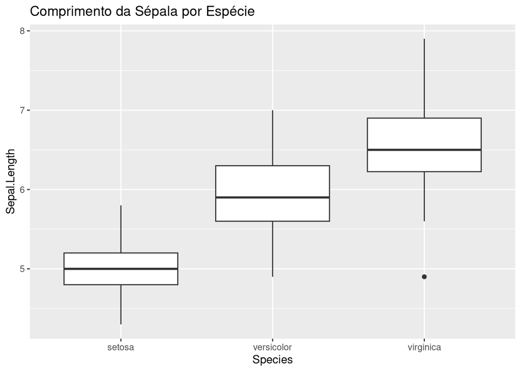

```r
#3)

# Carregando o conjunto de dados Iris
data("iris")

# Gráfico 1: Boxplot da comprimento da sépala por espécie de flor
ggplot(data = iris, aes(x = Species, y = Sepal.Length)) +
  geom_boxplot() +
  ggtitle("Comprimento da Sépala por Espécie")
```

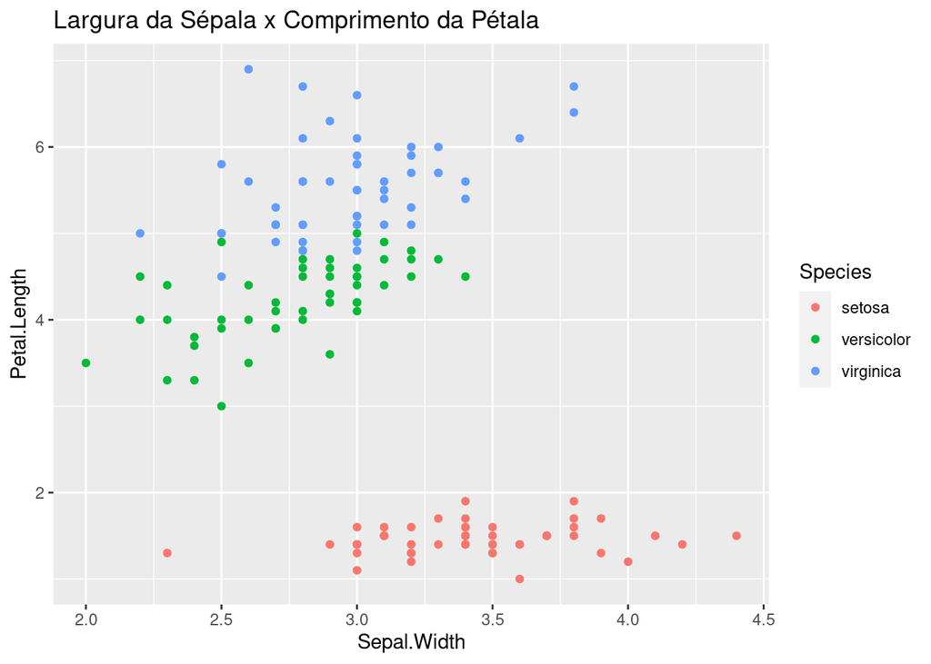

```r
# Gráfico 2: Dispersão entre largura da sépala e comprimento da pétala
ggplot(data = iris, aes(x = Sepal.Width, y = Petal.Length, color = Species)) +
  geom_point() +
  ggtitle("Largura da Sépala x Comprimento da Pétala")
```

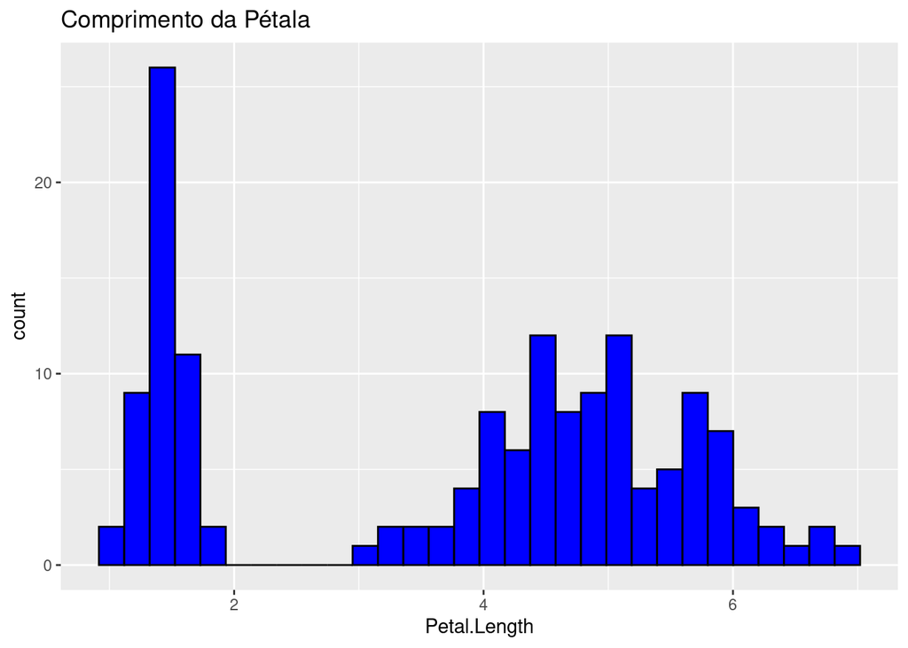

```r
# Gráfico 3: Histograma do comprimento da pétala
ggplot(data = iris, aes(x = Petal.Length)) +
  geom_histogram(fill = "blue", color = "black") +
  ggtitle("Comprimento da Pétala")
```

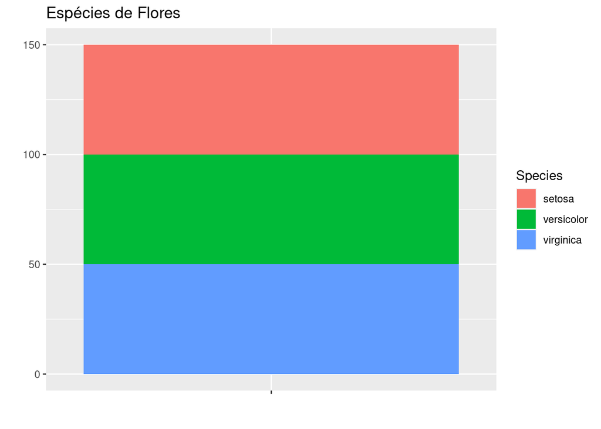

```r
# Gráfico 4: Diagrama de setores com a proporção de flores por espécie
ggplot(data = iris, aes(x = "", fill = Species)) +
  geom_bar(width = 1) +
  ggtitle("Espécies de Flores") +
  xlab("") + ylab("")
```

Em resumo, os gráficos nos mostram que existem diferenças entre as espécies de flor quanto ao comprimento da sépala, relação entre largura da sépala e comprimento da pétala e comprimento da pétala e a proporção de flores por espécie é semelhante.

## Exercício 04

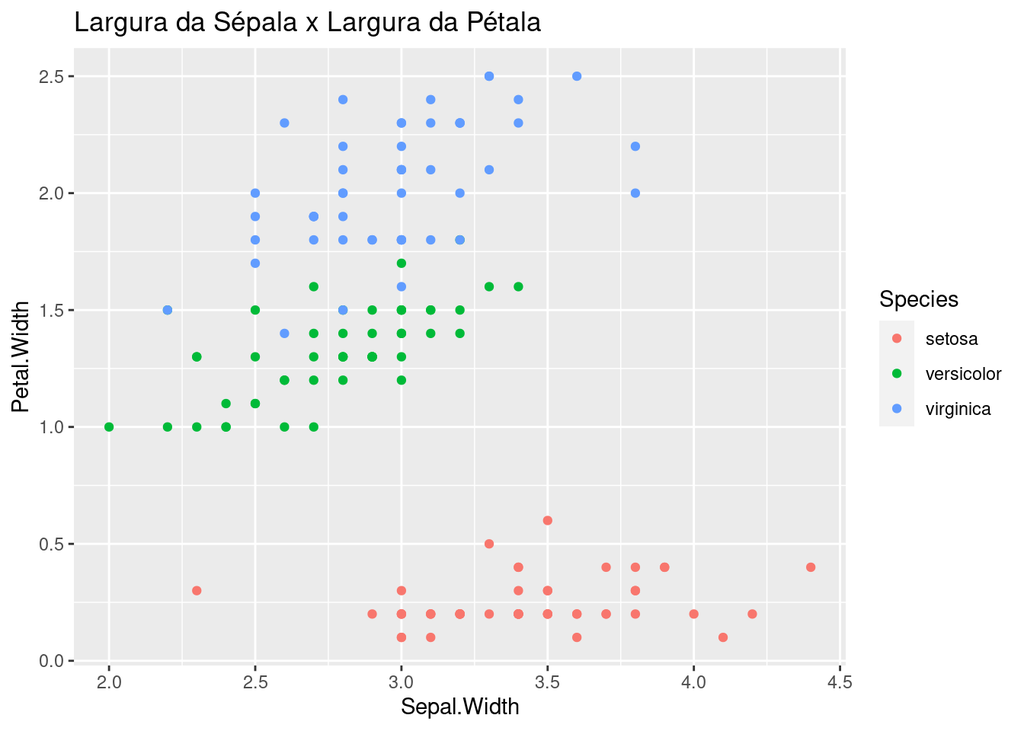

```r
#4)
ggplot(data = iris, aes(x = Sepal.Width, y = Petal.Width, color = Species)) +
  geom_point() +
  ggtitle("Largura da Sépala x Largura da Pétala")
```

## Exercício 05

O comando “?mpg” no R fornece informações sobre o conjunto de dados “mpg”, que contém informações sobre carros como fabricante, modelo, cilindrada, consumo de combustível, entre outros. As variáveis contidas neste banco de dados são:

manufacturer: fabricante do carro model: modelo do carro displ: cilindrada do motor, em litros year: ano de fabricação cyl: número de cilindros do motor trans: tipo de transmissão drv: tração (4x4, frente, traseira) cty: consumo de combustível na cidade, em milhas por galão hwy: consumo de combustível na estrada, em milhas por galão fl: tipo de combustível (gas, diesel, etc) class: classe do carro (compacto, suv, etc) Para fazer uma análise preliminar deste banco de dados, podemos usar os comandos head() e tail() para visualizar as primeiras e últimas linhas do conjunto de dados, respectivamente:

```r
# Visualizando as primeiras linhas do banco de dados
head(mpg)
```

```
## # A tibble: 6 × 11
##   manufacturer model displ  year   cyl trans      drv     cty   hwy fl    class
##   <chr>        <chr> <dbl> <int> <int> <chr>      <chr> <int> <int> <chr> <chr>
## 1 audi         a4      1.8  1999     4 auto(l5)   f        18    29 p     compa…
## 2 audi         a4      1.8  1999     4 manual(m5) f        21    29 p     compa…
## 3 audi         a4      2    2008     4 manual(m6) f        20    31 p     compa…
## 4 audi         a4      2    2008     4 auto(av)   f        21    30 p     compa…
## 5 audi         a4      2.8  1999     6 auto(l5)   f        16    26 p     compa…
## 6 audi         a4      2.8  1999     6 manual(m5) f        18    26 p     compa…
```

```r
# Visualizando as últimas linhas do banco de dados
tail(mpg)
```

```
## # A tibble: 6 × 11
##   manufacturer model  displ  year   cyl trans      drv     cty   hwy fl    class
##   <chr>        <chr>  <dbl> <int> <int> <chr>      <chr> <int> <int> <chr> <chr>
## 1 volkswagen   passat   1.8  1999     4 auto(l5)   f        18    29 p     mids…
## 2 volkswagen   passat   2    2008     4 auto(s6)   f        19    28 p     mids…
## 3 volkswagen   passat   2    2008     4 manual(m6) f        21    29 p     mids…
## 4 volkswagen   passat   2.8  1999     6 auto(l5)   f        16    26 p     mids…
## 5 volkswagen   passat   2.8  1999     6 manual(m5) f        18    26 p     mids…
## 6 volkswagen   passat   3.6  2008     6 auto(s6)   f        17    26 p     mids…
```

Também podemos usar o comando str() para obter uma visão geral das variáveis e seus tipos:

```r
str(mpg)
```

```
## tibble [234 × 11] (S3: tbl_df/tbl/data.frame)
##  $ manufacturer: chr [1:234] "audi" "audi" "audi" "audi" ...
##  $ model       : chr [1:234] "a4" "a4" "a4" "a4" ...
##  $ displ       : num [1:234] 1.8 1.8 2 2 2.8 2.8 3.1 1.8 1.8 2 ...
##  $ year        : int [1:234] 1999 1999 2008 2008 1999 1999 2008 1999 1999 2008 ...
##  $ cyl         : int [1:234] 4 4 4 4 6 6 6 4 4 4 ...
##  $ trans       : chr [1:234] "auto(l5)" "manual(m5)" "manual(m6)" "auto(av)" ...
##  $ drv         : chr [1:234] "f" "f" "f" "f" ...
##  $ cty         : int [1:234] 18 21 20 21 16 18 18 18 16 20 ...
##  $ hwy         : int [1:234] 29 29 31 30 26 26 27 26 25 28 ...
##  $ fl          : chr [1:234] "p" "p" "p" "p" ...
##  $ class       : chr [1:234] "compact" "compact" "compact" "compact" ...
```

Além disso, podemos usar os comandos summary() e dim() para obter informações estatísticas gerais sobre as variáveis e o tamanho do conjunto de dados, respectivamente:

```r
# Estatísticas gerais das variáveis
summary(mpg)
```

```
##  manufacturer          model               displ            year
##  Length:234         Length:234         Min.   :1.600   Min.   :1999
##  Class :character   Class :character   1st Qu.:2.400   1st Qu.:1999
##  Mode  :character   Mode  :character   Median :3.300   Median :2004
##                                        Mean   :3.472   Mean   :2004
##                                        3rd Qu.:4.600   3rd Qu.:2008
##                                        Max.   :7.000   Max.   :2008
##       cyl           trans               drv                 cty
##  Min.   :4.000   Length:234         Length:234         Min.   : 9.00
##  1st Qu.:4.000   Class :character   Class :character   1st Qu.:14.00
##  Median :6.000   Mode  :character   Mode  :character   Median :17.00
##  Mean   :5.889                                         Mean   :16.86
##  3rd Qu.:8.000                                         3rd Qu.:19.00
##  Max.   :8.000                                         Max.   :35.00
##       hwy             fl               class
##  Min.   :12.00   Length:234         Length:234
##  1st Qu.:18.00   Class :character   Class :character
##  Median :24.00   Mode  :character   Mode  :character
##  Mean   :23.44
##  3rd Qu.:27.00
##  Max.   :44.00
```

```r
# Tamanho do conjunto de dados
dim(mpg)
```

```
## [1] 234  11
```

Esse banco de dados contém informações sobre 234 carros, incluindo fabricante, modelo, cilindrada, consumo de combustível, entre outros. Cada carro tem informações sobre 11 variáveis diferentes, como fabricante, modelo, cilindrada, consumo de combustível, entre outros. Com essas informações é possível analisar características dos veículos e sua relação com o consumo de combustível, por exemplo.

## Exercício 06

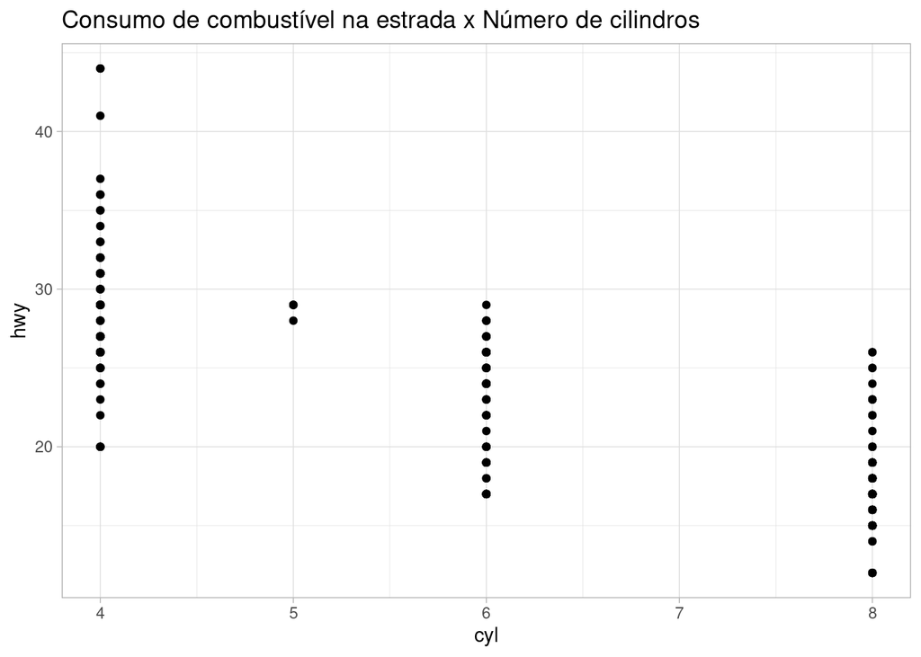

```r
data(mpg)
ggplot(data = mpg, aes(x = cyl, y = hwy)) +
  geom_point() +
  theme_light() +
  ggtitle("Consumo de combustível na estrada x Número de cilindros")
```

## Exercício 07

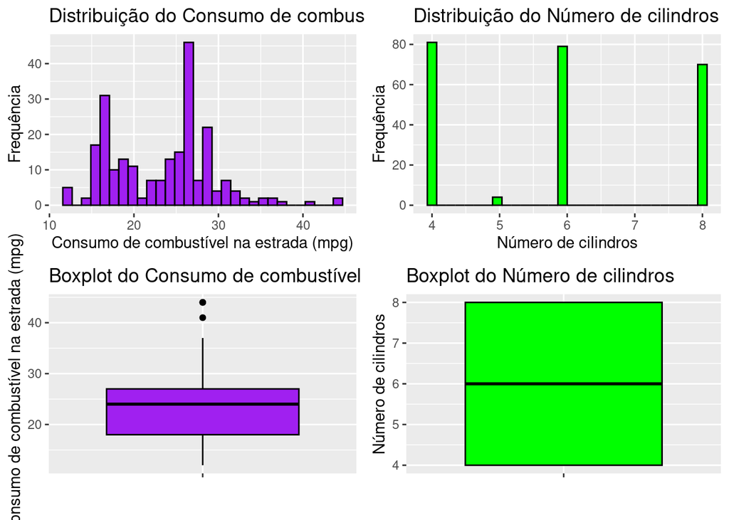

```r
library(gridExtra)

# Criando o histograma da variável hwy
hist_hwy <- ggplot(data = mpg, aes(x = hwy)) +
  geom_histogram(fill = "purple", color = "black") +
  xlab("Consumo de combustível na estrada (mpg)") +
  ylab("Frequência") +
  ggtitle("Distribuição do Consumo de combustível na estrada")

# Criando o histograma da variável cyl
hist_cyl <- ggplot(data = mpg, aes(x = cyl)) +
  geom_histogram(fill = "green", color = "black") +
  xlab("Número de cilindros") +
  ylab("Frequência") +
  ggtitle("Distribuição do Número de cilindros")

# Criando o boxplot da variável hwy
box_hwy <- ggplot(data = mpg, aes(x = "", y = hwy)) +
  geom_boxplot(fill = "purple", color = "black") +
  xlab("") +
  ylab("Consumo de combustível na estrada (mpg)") +
  ggtitle("Boxplot do Consumo de combustível na estrada")

# Criando o boxplot da variável cyl
box_cyl <- ggplot(data = mpg, aes(x = "", y = cyl)) +
  geom_boxplot(fill = "green", color = "black") +
  xlab("") +
  ylab("Número de cilindros") +
  ggtitle("Boxplot do Número de cilindros")

# Organizando os gráficos em subplots
grid.arrange(hist_hwy, hist_cyl, box_hwy, box_cyl, ncol = 2)
```

Os gráficos estão organizados em duas colunas, cada coluna com um histograma e um boxplot.

## Exercício 08

# 1)

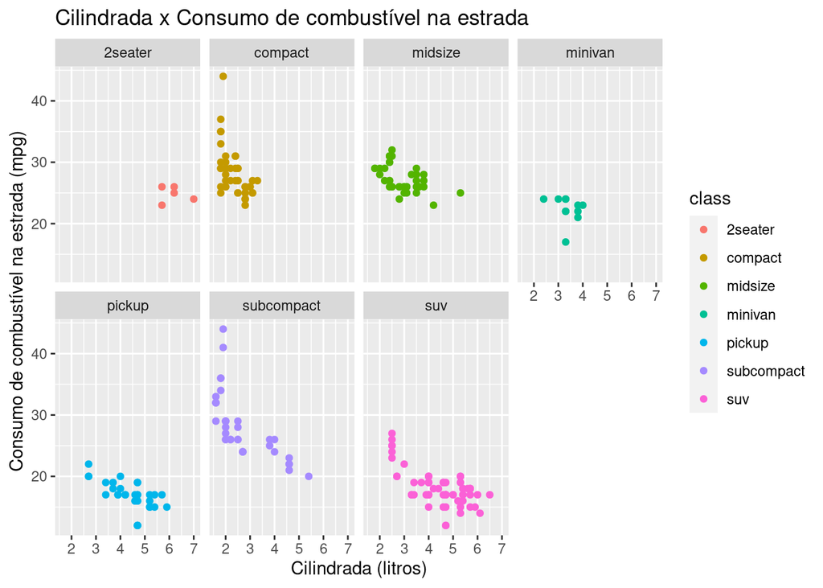

```r
# Criando o gráfico de dispersão
grafico <- ggplot(data = mpg, aes(x = displ, y = hwy, color = class)) +
  geom_point() +
  ggtitle("Cilindrada x Consumo de combustível na estrada") +
  xlab("Cilindrada (litros)") + ylab("Consumo de combustível na estrada (mpg)")

# Criando os subplots para cada classe de veículos
grafico + facet_wrap(~class,nrow = 2)
```

## 2)

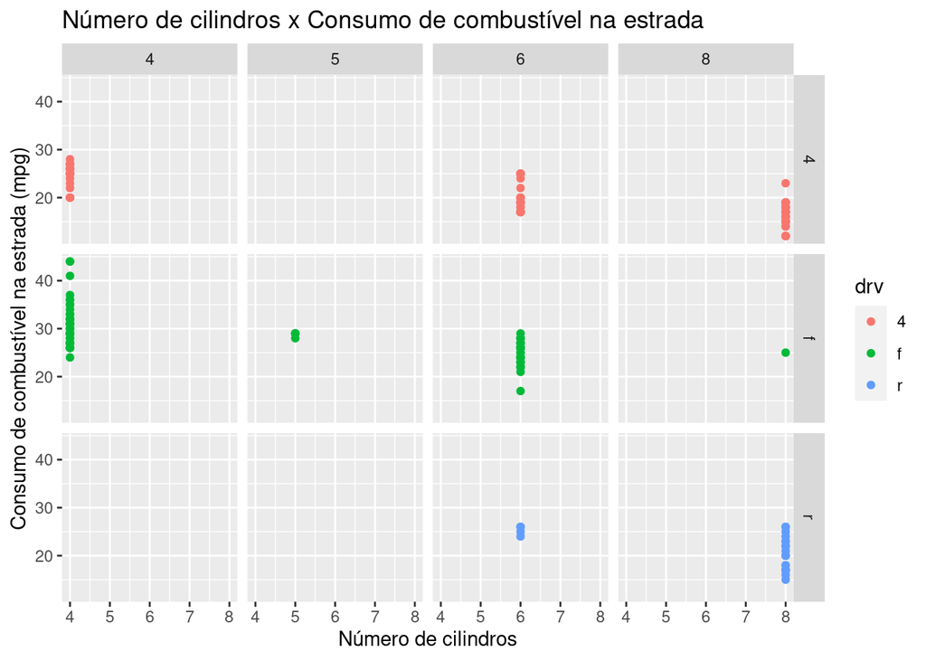

```r
# Criando o gráfico de dispersão
grafico2 <- ggplot(data = mpg, aes(x = cyl, y = hwy, color = drv)) +
  geom_point() +
  ggtitle("Número de cilindros x Consumo de combustível na estrada") +
  xlab("Número de cilindros") + ylab("Consumo de combustível na estrada (mpg)")

# Criando os subplots baseados nas variáveis cyl e drv
grafico2 +  facet_grid(drv ~ cyl)
```

## 3)

Se usarmos “color=cyl” para classificar por cilindros (cyl) e “facet_grid(. ~ cyl)”, cada ponto no gráfico será colorido de acordo com o número de cilindros do carro. Isso permitirá que você veja visualmente como o número de cilindros está relacionado a outra variável (neste caso, o consumo de combustível na estrada).

E o comando “facet_grid(. ~ cyl)” irá criar subplots para cada número de cilindros. Isto é, irá separar o gráfico em vários subplots para cada valor possível de cilindros. Cada subplot mostrará a relação entre o consumo de combustível na estrada e o número de cilindros, mas apenas para os carros com o número de cilindros específico. Assim, é possível observar como a relação entre as variáveis se comporta para cada valor de cilindros.